# NYPDShooting

C. Knowles

2023-11-01

## NYPD Shooting l

### Cleaning the Data

```r
shooting_csv <- read.csv("https://data.cityofnewyork.us/api/views/833y-fsy8/rows.csv?accessType=DOWNLOAD")
head(shooting_csv)
```

```
##   INCIDENT_KEY OCCUR_DATE OCCUR_TIME     BORO LOC_OF_OCCUR_DESC PRECINCT
## 1    228798151 05/27/2021   21:30:00   QUEENS                        105
## 2    137471050 06/27/2014   17:40:00    BRONX                         40
## 3    147998800 11/21/2015   03:56:00   QUEENS                        108
## 4    146837977 10/09/2015   18:30:00    BRONX                         44
## 5     58921844 02/19/2009   22:58:00    BRONX                         47
## 6    219559682 10/21/2020   21:36:00 BROOKLYN                         81
##   JURISDICTION_CODE LOC_CLASSFCTN_DESC LOCATION_DESC STATISTICAL_MURDER_FLAG
## 1                 0                                                    false
## 2                 0                                                    false
## 3                 0                                                     true
## 4                 0                                                    false
## 5                 0                                                     true
## 6                 0                                                     true
##   PERP_AGE_GROUP PERP_SEX PERP_RACE VIC_AGE_GROUP VIC_SEX       VIC_RACE
```

[output cut: 20 more lines]

```r
summary(shooting_csv)
```

```
##   INCIDENT_KEY        OCCUR_DATE         OCCUR_TIME            BORO
##  Min.   :  9953245   Length:27312       Length:27312       Length:27312
##  1st Qu.: 63860880   Class :character   Class :character   Class :character
##  Median : 90372218   Mode  :character   Mode  :character   Mode  :character
##  Mean   :120860536
##  3rd Qu.:188810230
##  Max.   :261190187
##
##  LOC_OF_OCCUR_DESC     PRECINCT      JURISDICTION_CODE LOC_CLASSFCTN_DESC
##  Length:27312       Min.   :  1.00   Min.   :0.0000    Length:27312
##  Class :character   1st Qu.: 44.00   1st Qu.:0.0000    Class :character
##  Mode  :character   Median : 68.00   Median :0.0000    Mode  :character
##                     Mean   : 65.64   Mean   :0.3269
##                     3rd Qu.: 81.00   3rd Qu.:0.0000
##                     Max.   :123.00   Max.   :2.0000
##                                      NA's   :2
##  LOCATION_DESC      STATISTICAL_MURDER_FLAG PERP_AGE_GROUP
##  Length:27312       Length:27312            Length:27312
##  Class :character   Class :character        Class :character
##  Mode  :character   Mode  :character        Mode  :character
##
##
##
##
##    PERP_SEX          PERP_RACE         VIC_AGE_GROUP        VIC_SEX
##  Length:27312       Length:27312       Length:27312       Length:27312
##  Class :character   Class :character   Class :character   Class :character
##  Mode  :character   Mode  :character   Mode  :character   Mode  :character
##
##
##
##
##    VIC_RACE           X_COORD_CD        Y_COORD_CD        Latitude
##  Length:27312       Min.   : 914928   Min.   :125757   Min.   :40.51
##  Class :character   1st Qu.:1000029   1st Qu.:182834   1st Qu.:40.67
##  Mode  :character   Median :1007731   Median :194487   Median :40.70
##                     Mean   :1009449   Mean   :208127   Mean   :40.74
##                     3rd Qu.:1016838   3rd Qu.:239518   3rd Qu.:40.82
##                     Max.   :1066815   Max.   :271128   Max.   :40.91
##                                                        NA's   :10
##    Longitude        Lon_Lat
##  Min.   :-74.25   Length:27312
##  1st Qu.:-73.94   Class :character
##  Median :-73.92   Mode  :character
##  Mean   :-73.91
##  3rd Qu.:-73.88
##  Max.   :-73.70
##  NA's   :10
```

```r
str(shooting_csv)
```

```
## 'data.frame':    27312 obs. of  21 variables:
##  $ INCIDENT_KEY           : int  228798151 137471050 147998800 146837977 58921844 219559682 85295722 71662474 83002139 86437261 ...
##  $ OCCUR_DATE             : chr  "05/27/2021" "06/27/2014" "11/21/2015" "10/09/2015" ...
##  $ OCCUR_TIME             : chr  "21:30:00" "17:40:00" "03:56:00" "18:30:00" ...
##  $ BORO                   : chr  "QUEENS" "BRONX" "QUEENS" "BRONX" ...
##  $ LOC_OF_OCCUR_DESC      : chr  "" "" "" "" ...
##  $ PRECINCT               : int  105 40 108 44 47 81 114 81 105 101 ...
##  $ JURISDICTION_CODE      : int  0 0 0 0 0 0 0 0 0 0 ...
##  $ LOC_CLASSFCTN_DESC     : chr  "" "" "" "" ...
##  $ LOCATION_DESC          : chr  "" "" "" "" ...
##  $ STATISTICAL_MURDER_FLAG: chr  "false" "false" "true" "false" ...
##  $ PERP_AGE_GROUP         : chr  "" "" "" "" ...
##  $ PERP_SEX               : chr  "" "" "" "" ...
##  $ PERP_RACE              : chr  "" "" "" "" ...
##  $ VIC_AGE_GROUP          : chr  "18-24" "18-24" "25-44" "<18" ...
##  $ VIC_SEX                : chr  "M" "M" "M" "M" ...
##  $ VIC_RACE               : chr  "BLACK" "BLACK" "WHITE" "WHITE HISPANIC" ...
##  $ X_COORD_CD             : num  1058925 1005028 1007668 1006537 1024922 ...
##  $ Y_COORD_CD             : num  180924 234516 209837 244511 262189 ...
##  $ Latitude               : num  40.7 40.8 40.7 40.8 40.9 ...
##  $ Longitude              : num  -73.7 -73.9 -73.9 -73.9 -73.9 ...
##  $ Lon_Lat                : chr  "POINT (-73.73083868899994 40.662964620000025)" "POINT (-73.92494232599995 40.81035186300006)" "POINT (-73.91549174199997 40.74260663300004)" "POINT (-73.91945661499994 40.83778200300003)" ...
```

Here my approach is to first remove any columns that will be unnecessary for analysis - LOC_OF_OCCUR_DESC, PRECINCT, JURISDICTION_CODE, LOC_CLASSFCTN_DESC, LOCATION_DESC, STATISTICAL_MURDER_FLAG, X_COORD_CD, Y_COORD_CD, Latitude, Longitude, and Lon_Lat.

```r
shoot <- distinct(shooting_csv) %>%
          select(OCCUR_DATE, OCCUR_TIME, BORO, PERP_AGE_GROUP, PERP_SEX, PERP_RACE, VIC_AGE_GROUP, VIC_SEX, VIC_RACE)
```

Next, I want to remove any rows that contain typos, missing, or ‘UNKNOWN’ data. I chose not to impute missing data because all missing values are strictly categorical and trying to predict what is missing is futile.

```r
filter_values <- c("", "UNKNOWN", "(null)", "U")
cleaned_shoot <- shoot %>% filter(!(BORO %in% filter_values) &
                                    !(PERP_AGE_GROUP %in% c(filter_values, "1020", "224", "940")) &
                                    !(PERP_SEX %in% filter_values) &
                                    !(PERP_RACE %in% filter_values) &
                                    !(VIC_AGE_GROUP %in% c(filter_values, "1022")) &
                                    !(VIC_SEX %in% filter_values) &
                                    !(VIC_RACE %in% filter_values))

#cleaned_shoot <- cleaned_shoot %>% filter(PERP_AGE_GROUP == 1 & VIC_AGE_GROUP == 1)
```

Now that my data set is cleaned, I want to transform it into a format that will be easier to work with going forward. I started by converting the OCCUR_DATE column to a date type, the OCCUR_TIME column to a time type, and the remaining columns to a factor type. This will allow me to easily sort and group our categorical data for visuals.

```r
glimpse(cleaned_shoot)
```

```
## Rows: 13,936
## Columns: 9
## $ OCCUR_DATE     <chr> "02/19/2009", "08/26/2012", "08/29/2010", "07/27/2010",…
## $ OCCUR_TIME     <chr> "22:58:00", "01:10:00", "01:27:00", "02:22:00", "21:17:…
## $ BORO           <chr> "BRONX", "QUEENS", "BROOKLYN", "MANHATTAN", "BROOKLYN",…
## $ PERP_AGE_GROUP <chr> "25-44", "25-44", "25-44", "25-44", "25-44", "18-24", "…
## $ PERP_SEX       <chr> "M", "M", "M", "M", "M", "M", "M", "F", "M", "M", "M", …
## $ PERP_RACE      <chr> "BLACK", "BLACK", "BLACK", "BLACK", "BLACK", "BLACK", "…
## $ VIC_AGE_GROUP  <chr> "45-64", "25-44", "25-44", "25-44", "25-44", "18-24", "…
## $ VIC_SEX        <chr> "M", "M", "M", "M", "M", "F", "M", "M", "M", "M", "M", …
## $ VIC_RACE       <chr> "BLACK", "BLACK", "BLACK", "BLACK", "WHITE", "BLACK", "…
```

```r
cols_to_convert <- c("BORO", "PERP_AGE_GROUP", "PERP_SEX", "PERP_RACE", "VIC_AGE_GROUP", "VIC_SEX", "VIC_RACE")
cleaned_shoot[cols_to_convert] <- lapply(cleaned_shoot[cols_to_convert], as.factor)
cleaned_shoot$OCCUR_DATE <- as.Date(cleaned_shoot$OCCUR_DATE, format = "%m/%d/%Y")
cleaned_shoot$OCCUR_TIME <- as_hms(cleaned_shoot$OCCUR_TIME)
shoot_tibble <- as_tibble(cleaned_shoot)
shoot_tibble
```

```
## # A tibble: 13,936 × 9
##    OCCUR_DATE OCCUR_TIME BORO    PERP_AGE_GROUP PERP_SEX PERP_RACE VIC_AGE_GROUP
##    <date>     <time>     <fct>   <fct>          <fct>    <fct>     <fct>
##  1 2009-02-19 22:58      BRONX   25-44          M        BLACK     45-64
##  2 2012-08-26 01:10      QUEENS  25-44          M        BLACK     25-44
##  3 2010-08-29 01:27      BROOKL… 25-44          M        BLACK     25-44
##  4 2010-07-27 02:22      MANHAT… 25-44          M        BLACK     25-44
##  5 2021-03-07 21:17      BROOKL… 25-44          M        BLACK     25-44
##  6 2015-02-01 23:16      MANHAT… 18-24          M        BLACK     18-24
##  7 2007-10-11 20:11      BRONX   45-64          M        BLACK     25-44
##  8 2016-03-28 19:10      BRONX   25-44          F        BLACK HI… 45-64
##  9 2013-03-06 04:08      QUEENS  25-44          M        BLACK HI… 25-44
## 10 2006-01-21 21:49      MANHAT… 18-24          M        BLACK     18-24
## # ℹ 13,926 more rows
## # ℹ 2 more variables: VIC_SEX <fct>, VIC_RACE <fct>
```

The following questions will be explored in this analysis

1. Does one race make up the majority of perpetrators?  
   1b) … majority of victims?  
   1c) Is this proportional to a borough’s racial demographic?
2. Do shootings occur significantly more among a specific age group?  
   2b) … among sex?  
   2c) … among race?
3. Do shootings occur significantly more in one month/s versus others?  
   3b) … in one time of day versus others?
4. Are there any confounding variables we must consider?

```r
boro_counts <- count(shoot_tibble, BORO)
print(boro_counts)
```

```
## # A tibble: 5 × 2
##   BORO              n
##   <fct>         <int>
## 1 BRONX          4316
## 2 BROOKLYN       4935
## 3 MANHATTAN      2047
## 4 QUEENS         2068
## 5 STATEN ISLAND   570
```

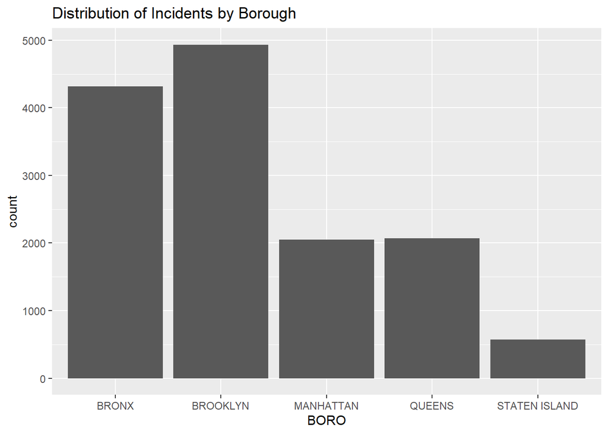

```r
ggplot(shoot_tibble, aes(x = BORO)) +
  geom_bar() +
  labs(title = "Distribution of Incidents by Borough")
```

```r
cross_tab <- table(shoot_tibble$BORO, shoot_tibble$PERP_AGE_GROUP)
print(cross_tab)
```

```
##
##                  <18 18-24 25-44 45-64  65+
##   BRONX          515  1950  1651   190   10
##   BROOKLYN       579  2174  1955   204   23
##   MANHATTAN      247   851   859    83    7
##   QUEENS         172   895   890    98   13
##   STATEN ISLAND   57   255   223    29    6
```

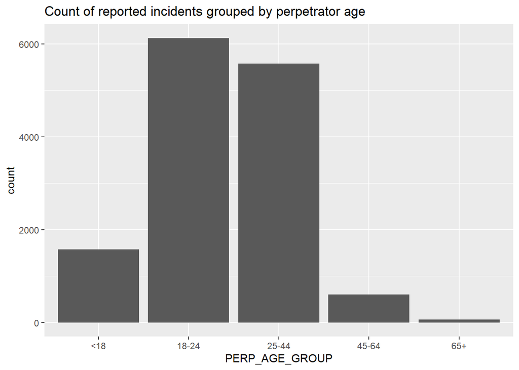

```r
ggplot(shoot_tibble, aes(x = PERP_AGE_GROUP)) +
  geom_bar() +
  labs(title = "Count of reported incidents grouped by perpetrator age")
```

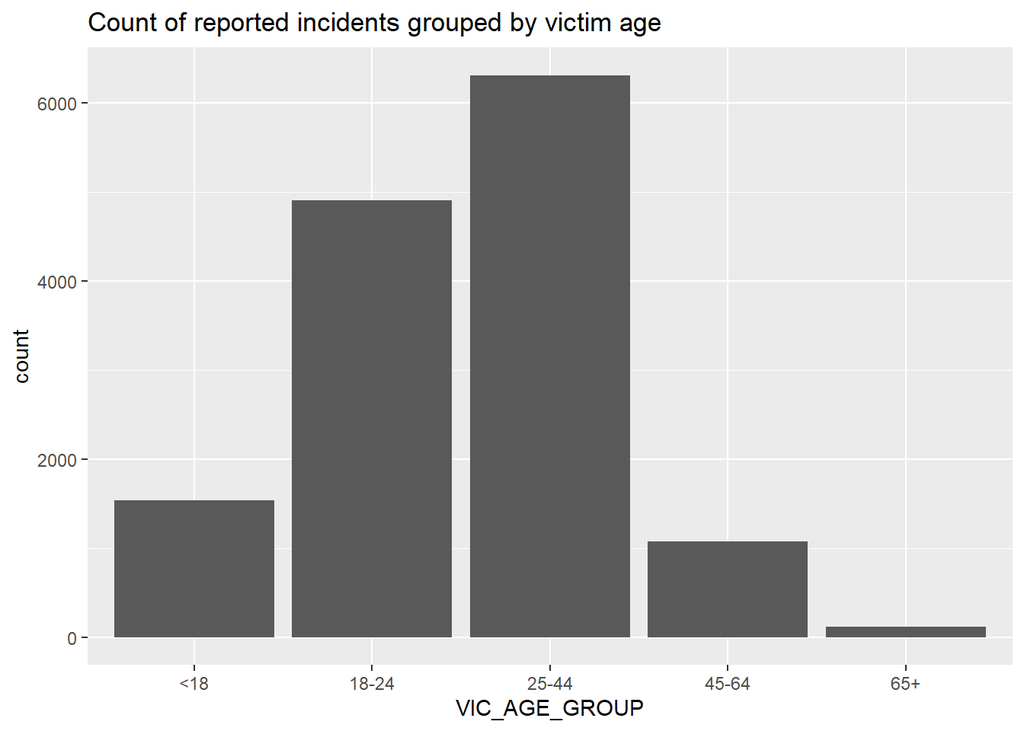

```r
ggplot(shoot_tibble, aes(x = VIC_AGE_GROUP)) +
  geom_bar() +
  labs(title = "Count of reported incidents grouped by victim age")
```

```r
chi_sqaure_result <- chisq.test(shoot_tibble$BORO, shoot_tibble$PERP_AGE_GROUP)
print(chi_sqaure_result)
```

```
##
##  Pearson's Chi-squared test
##
## data:  shoot_tibble$BORO and shoot_tibble$PERP_AGE_GROUP
## X-squared = 49.4, df = 16, p-value = 2.855e-05
```

```r
contingency_table <- table(shoot_tibble$BORO, shoot_tibble$PERP_AGE_GROUP)

fisher_result <- fisher.test(contingency_table, simulate.p.value = TRUE)
print(fisher_result)
```

```
##
##  Fisher's Exact Test for Count Data with simulated p-value (based on
##  2000 replicates)
##
## data:  contingency_table
## p-value = 0.0004998
## alternative hypothesis: two.sided
```

```r
chi_sqaure_result2 <- chisq.test(shoot_tibble$BORO, shoot_tibble$VIC_AGE_GROUP)
print(chi_sqaure_result2)
```

```
##
##  Pearson's Chi-squared test
##
## data:  shoot_tibble$BORO and shoot_tibble$VIC_AGE_GROUP
## X-squared = 45.497, df = 16, p-value = 0.0001164
```

```r
chi_sqaure_result3 <- chisq.test(shoot_tibble$PERP_AGE_GROUP, shoot_tibble$VIC_AGE_GROUP)
print(chi_sqaure_result3)
```

```
##
##  Pearson's Chi-squared test
##
## data:  shoot_tibble$PERP_AGE_GROUP and shoot_tibble$VIC_AGE_GROUP
## X-squared = 2377.8, df = 16, p-value < 2.2e-16
```

For each chi square test we reject the null hypothesis, therefore, there is a relationship between BORO v.s. PERP_AGE_GROUP, BORO v.s. VIC_AGE_GROUP, and PERP_AGE_GROUP v.s. VIC_AGE_GROUP.